# Homework 4 (Data Wrangling) by Cininta Pertiwi

### Strings in R: R4DS Exercises

#### **# 1**

Available at the following github link: [github.com/cnpw es207hw4/](https://github.com/cnpw/es207_hw4)

### More with Data Wrangling: Air Quality Data

```r
library(tidyverse)
library(data.table)
```

```r
library(dplyr)
library(lubridate)
```

```r
require(readr)
```

```r
setwd("ca_ozone")
```

```r
o3.filenames <- list.files(pattern = ".txt")
o3.filelist <- lapply(o3.filenames, read_delim, delim = "|")
```

#### **# 2**

The o3.filelist class is a list. It contains a list of the contents of each `.txt` data file in the form of a data frame.

```r
class(o3.filelist)
```

```
[1] "list"
```

#### **# 3**

Explain what each line of code is doing using ~ 1 sentence.

```r
# o3.filenames <- list.files(pattern = ".txt")
# This line creates a list of the names of the data files where it searches for the file
# names by searching files that are .txt.
# o3.filelist <- lapply(o3.filenames, read_delim, delim = "|")
# This line creates a list containing all the datatsets that were read in where for each list the data is read in by identifying its delimiter "|".
# names(o3.filelist) <- gsub(".txt","", o3.filenames)
# This line removes the .txt from the names of the files (in this case the lists in o3.filelist) by replacing the .txt with empty characters.
```

#### **# 4**

Rewrite the code to change the names in o3.filelist with `str_replace()` instead of `gsub()`

```r
# use str_replace() instead of gsub()
# not run
# names(o3.filelist) <- str_replace(o3.filenames, "\\.txt", "")
```

#### **# 5**

```r
daily <- o3.filelist %>%
  rbindlist() %>%
  group_by(site = as.factor(site), date) %>%
  summarize(o3 = mean(obs, na.rm = TRUE))
head(daily)
```

| site | date | o3 |
| --- | --- | --- |
| 2001 | 1980-02-01 | 0.006521739 |
| 2001 | 1980-02-02 | 0.008260870 |
| 2001 | 1980-02-03 | 0.005652174 |
| 2001 | 1980-02-04 | 0.007826087 |
| 2001 | 1980-02-05 | 0.001000000 |
| 2001 | 1980-02-07 | 0.002222222 |

Rewrite above code using objects instead of piping.

```r
o3_big_list <- rbindlist(o3.filelist)
o3_by_date <- group_by(o3_big_list, site = as.factor(site), date)
daily_too <- summarize(o3_by_date, o3 = mean(obs, na.rm = TRUE))
# check daily
head(daily_too)
```

| site | date | o3 |
| --- | --- | --- |
| 2001 | 1980-02-01 | 0.006521739 |
| 2001 | 1980-02-02 | 0.008260870 |
| 2001 | 1980-02-03 | 0.005652174 |
| 2001 | 1980-02-04 | 0.007826087 |
| 2001 | 1980-02-05 | 0.001000000 |
| 2001 | 1980-02-07 | 0.002222222 |

#### **# 6**

Summarize the o3 data above by site and by month and by year using a piping operator (the monthly mean o3 for each site for each year).

```r
monthly <- o3.filelist %>%
  rbindlist() %>%
  mutate(year = lubridate::year(date)) %>%
  mutate(month = lubridate::month(date)) %>%
  group_by(site = as.factor(site), month, year) %>%
  summarize(o3 = mean(obs, na.rm = TRUE))
head(monthly)
```

| site | month | year | o3 |
| --- | --- | --- | --- |
| 2001 | 1 | 1981 | 0.008556851 |
| 2001 | 1 | 1982 | 0.012237960 |
| 2001 | 1 | 1983 | 0.012968491 |
| 2001 | 1 | 1984 | 0.014893314 |
| 2001 | 1 | 1985 | 0.013526912 |
| 2001 | 1 | 1986 | 0.012935252 |

#### **# 7**

Challenge! Ozone pollution actually follows a very strong diurnal pattern. How would you summarize the daily data from above in a better way to capture that diurnal pattern?

- I would group the data by hour:

```r
by_hour <- o3.filelist %>%
  rbindlist() %>%
  group_by(start_hour) %>%
  summarize(o3 = mean(obs, na.rm = TRUE))
head(by_hour)
```

| start_hour | o3 |
| --- | --- |
| 0 | 0.02041610 |
| 1 | 0.01968968 |
| 2 | 0.01941254 |
| 3 | 0.01905784 |
| 4 | 0.01818487 |
| 5 | 0.01629638 |

- Then use a graph to visualize the pattern:

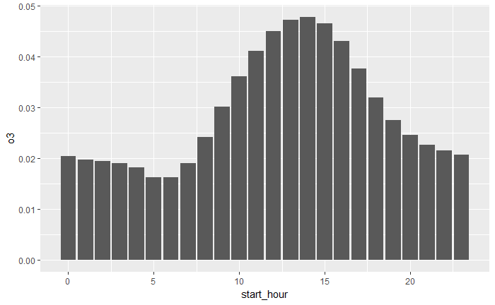

```r
ggplot(by_hour, aes(start_hour, o3)) + geom_bar(stat = 'identity')
```

**For #8 and #9: More with Strings!**

```r
library(readxl)
```

```r
setwd("ca_ozone")
```

[output not shown]

```r
loc <- read_excel("location.xls")
loc
```

| Location | Site | Site Name | Short Name | AIRS Site | AQD Site | County | County Abbr | County Name | Basin | Basin Name | District | District Name | PA8 | PA8 Name | State | MSA | MSA Name | AQCR | Urban Area | City | Address | Zip Code | Lat Degrees | Lat Minutes | Lat Seconds | Latitude | Long Degrees | Long Minutes | Long Seconds | … |
| --- | --- | --- | --- | --- | --- | --- | --- | --- | --- | --- | --- | --- | --- | --- | --- | --- | --- | --- | --- | --- | --- | --- | --- | --- | --- | --- | --- | --- | --- | --- |
| 2001 | 2001 | Citrus Heights-Sunrise Blvd | Citrus_Hghts | 060670001 | 3400293 | 34 | SAC | Sacramento | SV | Sacramento Valley | SAC | Sacramento County APCD | SMA8 | Sacramento Metropolitan Area | CA | 6920 | Sacramento | 28 | 6920 | 13588 | 7400 Sunrise Blvd | 95610 | 38 | 41 | 56.00 | 38.69889 | 121 | 16 | 15.99 | … |
| 2007 | 2007 | McCloud-Minnesota | McCloud-Minn | 060930002 | 4700867 | 47 | SIS | Siskiyou | NEP | Northeast Plateau | SIS | Siskiyou County APCD | NEP8 | Northeast Plateau | CA | 0 | Not in a MSA | 27 | 0 | 44784 | Minnesota Avenue | 35 | 41 | 16 | 15.99 | 41.27111 | 121 | 52 | 18.99 | … |
| 2008 | 2008 | El Capitan Beach | El_Capitan_B | 060830008 | 4200370 | 42 | SB | Santa Barbara | SCC | South Central Coast | SB | Santa Barbara County APCD | SB8 | Santa Barbara | CA | 7480 | Santa Barbara-Santa Maria-Lompoc | 32 | 7479 | 69070 | Location Approximate | 93117 | 34 | 27 | 44.00 | 34.46222 | 120 | 1 | 32.99 | … |
| 2011 | 2011 | Eureka-Fort Avenue | Eureka-FtAve | NA | 1200522 | 12 | HUM | Humboldt | NC | North Coast | NCU | North Coast Unified AQMD | NC8 | North Coast | CA | 0 | Not in a MSA | 0 | 0 | 23042 | Address Not Known | 95501 | 40 | 48 | 7.00 | 40.80194 | 124 | 9 | 46.99 | … |
| 2012 | 2012 | Fresno-Cal State #2 | Fresno-ClSt2 | 060190241 | 1000241 | 10 | FRE | Fresno | SJV | San Joaquin Valley | SJV | San Joaquin Valley Unified APCD | SJV8 | San Joaquin Valley | CA | 2840 | Fresno | 31 | 2840 | 27000 | East Shaw Avenue and North Maple Avenue | 93710 | 36 | 48 | 48.99 | 36.81361 | 119 | 44 | 24.99 | … |
| 2013 | 2013 | Fresno-Drummond Street | Fresno-Drmnd | 060190007 | 1000244 | 10 | FRE | Fresno | SJV | San Joaquin Valley | SJV | San Joaquin Valley Unified APCD | SJV8 | San Joaquin Valley | CA | 2840 | Fresno | 31 | 2840 | 27000 | 4706 East Drummond Avenue | 93725 | 36 | 42 | 19.99 | 36.70555 | 119 | 44 | 28.98 | … |
| 2014 | 2014 | Petaluma-Payran | Petaluma-Pyr | 060971002 | 4900883 | 49 | SON | Sonoma | SFB | San Francisco Bay Area | BA | Bay Area AQMD | SFB8 | San Francisco Bay Area | CA | 7500 | Santa Rosa | 30 | 0 | 56784 | 301 Payran Street | 94952 | 38 | 13 | 58.80 | 38.23300 | 122 | 38 | 9.60 | … |
| 2016 | 2016 | Carmel Valley-Ford Road | Carm_Val-Frd | 060530002 | 2700550 | 27 | MON | Monterey | NCC | North Central Coast | MBU | Monterey Bay Unified APCD | NCC8 | North Central Coast | CA | 7120 | Salinas | 25 | 0 | 11320 | 35 Ford Road | 93924 | 36 | 28 | 54.83 | 36.48190 | 121 | 43 | 59.88 | … |
| 2023 | 2023 | Independence-8 miles NNW-Pump #1 | Independ-8mi | 060270006 | 1400701 | 14 | INY | Inyo | GBV | Great Basin Valleys | GBU | Great Basin Unified APCD | GBV8 | Great Basin Valleys | CA | 0 | Not in a MSA | 23 | 0 | 36350 | Location Approximate | 93526 | 36 | 54 | 17.99 | 36.90500 | 117 | 45 | 39.99 | … |
| 2024 | 2024 | Burlingame-Burlingame Avenue | Burlngme-Ave | 060810002 | 4100545 | 41 | SM | San Mateo | SFB | San Francisco Bay Area | BA | Bay Area AQMD | SFB8 | San Francisco Bay Area | CA | 7360 | San Francisco | 30 | 7360 | 9066 | 1229 Burlingame Avenue | 94010 | 37 | 35 | 2.39 | 37.58400 | 122 | 21 | 54.00 | … |

[output cut: 911 more lines]

#### **# 8**

There are **89** site names that contain “San” or“Santa”. I specifically specified that the “San” and “Santa” are only in the beginning of the string to prevent detecting them within a word or as part of the street name (which some “Site Name” include). If this is not specified, there is 98 site names contaning the strings “San” or “Santa”.

```r
# specified only beginning of each string
sum(str_detect(loc$`Site Name`, "^(San|Santa)") == TRUE)
```

```
[1] 89
```

```r
# not specified beginning of each string
sum(str_detect(loc$`Site Name`, "San|Santa") == TRUE)
```

```
[1] 98
```

#### **# 9**

- Filtering by steps through piping

```r
complete <- loc %>%
  filter(is.na(.$Address) == FALSE) %>%
  filter(is.na(.$`Zip Code`) == FALSE) %>%
  filter(str_detect(.$`Zip Code`, "\\d{5}") == TRUE) %>%
  filter(str_detect(.$Address, "^(\\d|PO)") == TRUE)
dim(complete)
```

```
[1] 500  36
```

- Combining regex into a single filter

```r
compl <- filter(loc, str_detect(loc$Address, "^(\\d|PO)") == TRUE
                & str_detect(loc$`Zip Code`, "\\d{5}") == TRUE)
dim(compl)
```

```
[1] 500  36
```

#### **# 10**

The difference between a semi join and an inner join is that for `semi_join()` the columns from the second tibble are not added into the joined tibble. Meanwhile for `inner_join()` the columns from the second tibble are added thus the joined tibble has both columns from the first and second tibbles.

**For #11 and #12: Manipulating your data**

```r
colnames(loc)[1] <- "site"
daily.site <- daily %>%
  left_join(loc, by = "site")
```

```
Column `site` joining factor and character vector, coercing into character vector
```

```r
daily.site
```

| site | date | o3 | Site | Site Name | Short Name | AIRS Site | AQD Site | County | County Abbr | County Name | Basin | Basin Name | District | District Name | PA8 | PA8 Name | State | MSA | MSA Name | AQCR | Urban Area | City | Address | Zip Code | Lat Degrees | Lat Minutes | Lat Seconds | Latitude | Long Degrees | … |
| --- | --- | --- | --- | --- | --- | --- | --- | --- | --- | --- | --- | --- | --- | --- | --- | --- | --- | --- | --- | --- | --- | --- | --- | --- | --- | --- | --- | --- | --- | --- |
| 2001 | 1980-02-01 | 0.0065217391 | 2001 | Citrus Heights-Sunrise Blvd | Citrus_Hghts | 060670001 | 3400293 | 34 | SAC | Sacramento | SV | Sacramento Valley | SAC | Sacramento County APCD | SMA8 | Sacramento Metropolitan Area | CA | 6920 | Sacramento | 28 | 6920 | 13588 | 7400 Sunrise Blvd | 95610 | 38 | 41 | 56 | 38.69889 | 121 | … |
| 2001 | 1980-02-02 | 0.0082608696 | 2001 | Citrus Heights-Sunrise Blvd | Citrus_Hghts | 060670001 | 3400293 | 34 | SAC | Sacramento | SV | Sacramento Valley | SAC | Sacramento County APCD | SMA8 | Sacramento Metropolitan Area | CA | 6920 | Sacramento | 28 | 6920 | 13588 | 7400 Sunrise Blvd | 95610 | 38 | 41 | 56 | 38.69889 | 121 | … |
| 2001 | 1980-02-03 | 0.0056521739 | 2001 | Citrus Heights-Sunrise Blvd | Citrus_Hghts | 060670001 | 3400293 | 34 | SAC | Sacramento | SV | Sacramento Valley | SAC | Sacramento County APCD | SMA8 | Sacramento Metropolitan Area | CA | 6920 | Sacramento | 28 | 6920 | 13588 | 7400 Sunrise Blvd | 95610 | 38 | 41 | 56 | 38.69889 | 121 | … |
| 2001 | 1980-02-04 | 0.0078260870 | 2001 | Citrus Heights-Sunrise Blvd | Citrus_Hghts | 060670001 | 3400293 | 34 | SAC | Sacramento | SV | Sacramento Valley | SAC | Sacramento County APCD | SMA8 | Sacramento Metropolitan Area | CA | 6920 | Sacramento | 28 | 6920 | 13588 | 7400 Sunrise Blvd | 95610 | 38 | 41 | 56 | 38.69889 | 121 | … |
| 2001 | 1980-02-05 | 0.0010000000 | 2001 | Citrus Heights-Sunrise Blvd | Citrus_Hghts | 060670001 | 3400293 | 34 | SAC | Sacramento | SV | Sacramento Valley | SAC | Sacramento County APCD | SMA8 | Sacramento Metropolitan Area | CA | 6920 | Sacramento | 28 | 6920 | 13588 | 7400 Sunrise Blvd | 95610 | 38 | 41 | 56 | 38.69889 | 121 | … |
| 2001 | 1980-02-07 | 0.0022222222 | 2001 | Citrus Heights-Sunrise Blvd | Citrus_Hghts | 060670001 | 3400293 | 34 | SAC | Sacramento | SV | Sacramento Valley | SAC | Sacramento County APCD | SMA8 | Sacramento Metropolitan Area | CA | 6920 | Sacramento | 28 | 6920 | 13588 | 7400 Sunrise Blvd | 95610 | 38 | 41 | 56 | 38.69889 | 121 | … |
| 2001 | 1980-02-08 | 0.0086666667 | 2001 | Citrus Heights-Sunrise Blvd | Citrus_Hghts | 060670001 | 3400293 | 34 | SAC | Sacramento | SV | Sacramento Valley | SAC | Sacramento County APCD | SMA8 | Sacramento Metropolitan Area | CA | 6920 | Sacramento | 28 | 6920 | 13588 | 7400 Sunrise Blvd | 95610 | 38 | 41 | 56 | 38.69889 | 121 | … |
| 2001 | 1980-02-11 | 0.0177777778 | 2001 | Citrus Heights-Sunrise Blvd | Citrus_Hghts | 060670001 | 3400293 | 34 | SAC | Sacramento | SV | Sacramento Valley | SAC | Sacramento County APCD | SMA8 | Sacramento Metropolitan Area | CA | 6920 | Sacramento | 28 | 6920 | 13588 | 7400 Sunrise Blvd | 95610 | 38 | 41 | 56 | 38.69889 | 121 | … |
| 2001 | 1980-02-12 | 0.0162500000 | 2001 | Citrus Heights-Sunrise Blvd | Citrus_Hghts | 060670001 | 3400293 | 34 | SAC | Sacramento | SV | Sacramento Valley | SAC | Sacramento County APCD | SMA8 | Sacramento Metropolitan Area | CA | 6920 | Sacramento | 28 | 6920 | 13588 | 7400 Sunrise Blvd | 95610 | 38 | 41 | 56 | 38.69889 | 121 | … |
| 2001 | 1980-02-13 | 0.0154166667 | 2001 | Citrus Heights-Sunrise Blvd | Citrus_Hghts | 060670001 | 3400293 | 34 | SAC | Sacramento | SV | Sacramento Valley | SAC | Sacramento County APCD | SMA8 | Sacramento Metropolitan Area | CA | 6920 | Sacramento | 28 | 6920 | 13588 | 7400 Sunrise Blvd | 95610 | 38 | 41 | 56 | 38.69889 | 121 | … |

[output cut: 990 more lines]

#### **# 11**

Function to calculate the annual mean, median, max and min of all sites that have “San” or “Santa” in their name. **Note** that the following function is only for the overall o3.filelist dataset since it contains variable names as specified in the dataset. It is not for use on a general dataset.

```r
annual_values <- function(df) {
  annual <- df %>%
    filter(str_detect(`Site Name`, "^(San|Santa)") == TRUE) %>%
    mutate(year = lubridate::year(date)) %>%
    group_by(year, `Site Name`) %>%
    summarize(Mean = mean(o3, na.rm = TRUE),
              Median = median(o3, na.rm = TRUE),
              Max = max(o3, na.rm = TRUE),
              Min = min(o3, na.rm = TRUE))
  return(annual)
}
av <- annual_values(daily.site)
av
```

| year | Site Name | Mean | Median | Max | Min |
| --- | --- | --- | --- | --- | --- |
| 1980 | San Bernardino | 0.039967164 | 0.029583333 | 0.131250000 | 0.000000e+00 |
| 1980 | San Bernardino-East 3rd | 0.013166667 | 0.012083333 | 0.017083333 | 1.000000e-02 |
| 1980 | San Bernardino-special study | 0.039967164 | 0.029583333 | 0.131250000 | 0.000000e+00 |
| 1980 | San Diego-Island Avenue | 0.029538103 | 0.027916667 | 0.078695652 | 5.416667e-03 |
| 1980 | San Diego-Overland Avenue | 0.031030077 | 0.029565217 | 0.077500000 | 4.583333e-03 |
| 1980 | San Francisco-23rd Street | 0.013372072 | 0.012500000 | 0.040416667 | 0.000000e+00 |
| 1980 | San Francisco-Ellis Street | 0.004020833 | 0.003125000 | 0.009583333 | 0.000000e+00 |
| 1980 | San Jose-1025 Piedmont Road | 0.019479267 | 0.019166667 | 0.075833333 | 0.000000e+00 |
| 1980 | San Jose-4th Street | 0.017457979 | 0.017083333 | 0.047083333 | 0.000000e+00 |
| 1980 | San Leandro | 0.015598312 | 0.014782609 | 0.040000000 | 0.000000e+00 |

[output cut: 558 more lines]

#### **# 12**

Function to caculate the annual daily mean. Apply that function to Merced County. **Note** that the following functions are only for the overall o3.filelist dataset since it contains variable names as specified in the dataset. It is not for use on a general dataset. I approached this problem in two ways:

- Finding a single overall annual daily mean value of o3 for Merced County. The value is 0.032.

```r
# function for overall annual daily mean
annual_daily_mean <- function(df) {
  annual <- df %>%
    mutate(year = lubridate::year(date)) %>%
    group_by(year) %>%                            # groups by year
    summarize(Mean_o3 = mean(o3, na.rm = TRUE))   # daily mean by year
  an_mean <- mean(annual$Mean_o3)                 # mean of daily mean by year
  return(an_mean)
}
# filter data for Merced County only
merced_o3 <- daily.site %>%
  filter(str_detect(`County Name`, "^Merced$") == TRUE)
# overall annual daily in Mercred County
merced_annual_daily <- annual_daily_mean(merced_o3)
merced_annual_daily
```

```
[1] 0.03202564
```

- Generating a tibble which gives the annualy daily mean values of o3 for every year. This gives the daily mean value for the particular years listed.

```r
# function for annual daily mean for each year
yearly_daily_mean <- function(df) {
  annual <- df %>%
    mutate(year = lubridate::year(date)) %>%
    group_by(year) %>%                            # groups by year
    summarize(Mean_o3 = mean(o3, na.rm = TRUE))   # daily mean by year
  return(annual)
}
# filter data for Merced County only
merced_o3 <- daily.site %>%
  filter(str_detect(`County Name`, "^Merced$") == TRUE)
# overall annual daily in Mercred County
merced_yearly_daily <- yearly_daily_mean(merced_o3)
merced_yearly_daily
```

| year | Mean_o3 |
| --- | --- |
| 1981 | 0.01871157 |
| 1982 | 0.03769584 |
| 1991 | 0.02926434 |
| 1992 | 0.03090583 |
| 1993 | 0.02979369 |
| 1994 | 0.03160586 |
| 1995 | 0.03426798 |
| 1996 | 0.03382698 |
| 1997 | 0.03192600 |
| 1998 | 0.03554296 |

[output cut: 13 more lines]